# A Risk-based Approach to R Validation

Workshop - R/Pharma 2020

October 6th, 2020

## Presenters

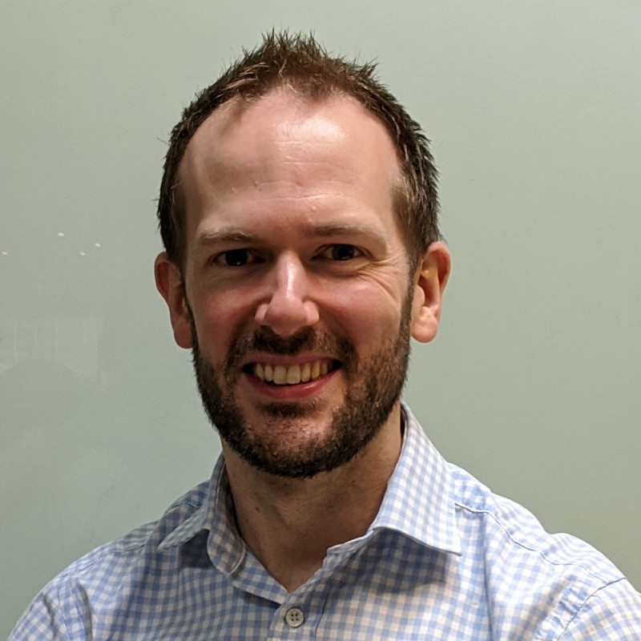

Andy Nicholls

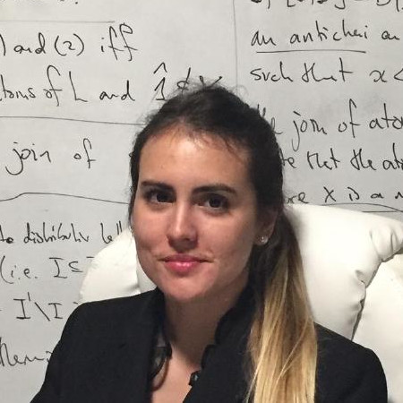

Marly Gotti

## Welcome

Thank you for enrolling in this workshop!

In this site you can find information about the workshop as well as the steps you need to follow to prepare for it.

## Overview

The workshop will last three hours, starting at **12pm EST** on **October 6th, 2020**.

In the workshop we will walk through an implementation of the R Validation Hub’s white paper: [A Risk-based Approach for Assessing R Package Accuracy within a Validated Infrastructure](https://www.pharmar.org/white-paper/). The workshop will explore two core themes:

1. R Packages Risk Assessment
2. Testing

In part 1, we will use a set of pre-selected R packages to see how the R Validation Hub’s Risk Assessment Application and the [riskmetric](https://pharmar.github.io/riskmetric/articles/riskmetric.html) R package can be used to create risk assessment reports for an R package.

In part 2, we will discuss how testing can be used to reduce the risk for those packages with high risk. In particular, we will discuss the testing philosophy with respect to software validation and demonstrate how the `testthat` package can be used to perform the necessary steps to follow traceability requirements. Prior knowledge of the basic structure of R packages is required for the second part of this workshop.

**Workshop Outline**

- Introduction - 15 mins
- Overview of the white paper - 20 mins
- BREAK - 10 mins
- Risk Assessment Tools - 30 mins
- Exercise - 30 mins
- BREAK - 10 mins
- Responding to Risk - 30 mins
- Exercise - 30 mins

## Slides/Video

- Introduction & Overview of the White Paper
- Risk Assessment Tools
- Responding to Risk: Testing (exercise materials can be found in the zip file test_exercise.zip)
- [Workshop Video](https://youtu.be/9AiJSEZAz4g)

## Prepare for the workshop

Before the workshop, please join the RStudio Cloud space [here](https://rstudio.cloud/spaces/94751/join?access_code=k%2F2tizN3wV8WABmBPwfvsV0jbitVdQ%2FTsJWHF5VJ).

After clicking the link you will be prompted to log in or create an account if you do not have one. Afterwards, you can click the button **Join Space**. On the Projects tab, you will see the project **Test framework**, which we will use in class.

*Optional:* If you have time to spare, you can get familiar with the white paper [A Risk-based Approach for Assessing R Package Accuracy within a Validated Infrastructure](https://www.pharmar.org/white-paper/)

## Resources

- Poll results from the workshop: poll results
- GitHub repository for [`riskmetric`](https://github.com/pharmaR/riskmetric)
- GitHub repository for the [Risk Assessment Shiny Application](https://github.com/pharmaR/risk_assessment)
- [R Validation Hub’s white paper](https://www.pharmar.org/white-paper/)
- PSI Special Interest Group paper: Application and Implementation of Methodologies in Statistics (AIMS)

## Acknowledgements

We would like to thank

- the R Validation Hub (PSI, EFR Consortium)
- the wonderful TA’s that were instrumental in facilitating the discussion during the exercises:
  - Keaven Anderson (MSD)
  - Yilong Zhang (MSD)
  - Paulo Bargo (Janssen)
  - Magda Zwierzyna (GSK)
  - Juliane Manitz (EMD Serono)
  - Eli Miller (Atorus Research)
- the team working on `riskmetric`
- the team working on the `Risk Assessment App`

Thanks to all those involved in pulling together the R/Pharma conference!

## About the R Validation Hub

R Validation Hub is a cross-industry initiative whose mission is to enable the use of R by the Bio-Pharmaceutical Industry in a regulatory setting, where the output may be used in submissions to regulatory agencies.

To learn more about the work we do, please go to pharmar.org.